# Vaccinated in ICUs - Greece

Kostas Voulgaropoulos

12/2/2022

## Purpose

The great bet with COVID is to avoid * overcrowding of Intensive Care Units (ICUs) and  
* exhaustion of medical personnel

Most scientists say that our **most powerful weapon** towards that cause is the **vaccine**.

Thankfully for us, the Greek Health Administration started (since August the 30th) publishing the numbers of vaccinated and unvaccinated patients in the country’s Intensive Care Units.

We will donwload all available daily reports that contain those figures to investigate who’s occupying the ICUs.

Vaxed, unvaxed or both?

## Absolute Numbers & Percentages

Now that we have fetched and cleaned our data, we can plot.

First, let’s take a look at the absolute numbers in ICUs.

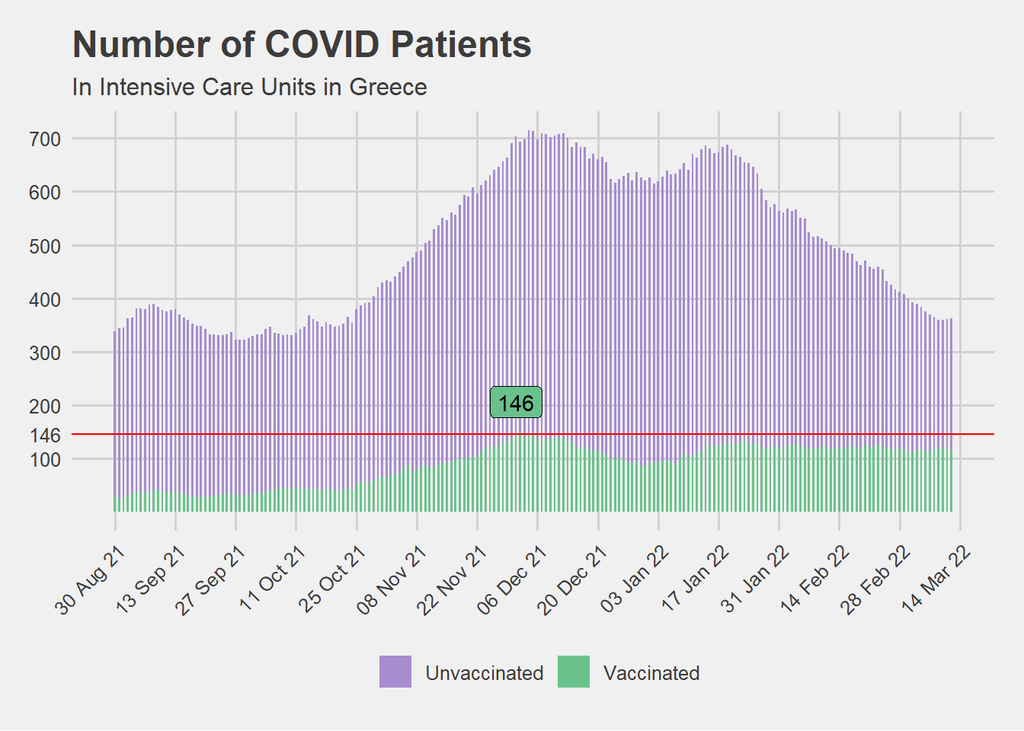

And one with Relative Numbers:

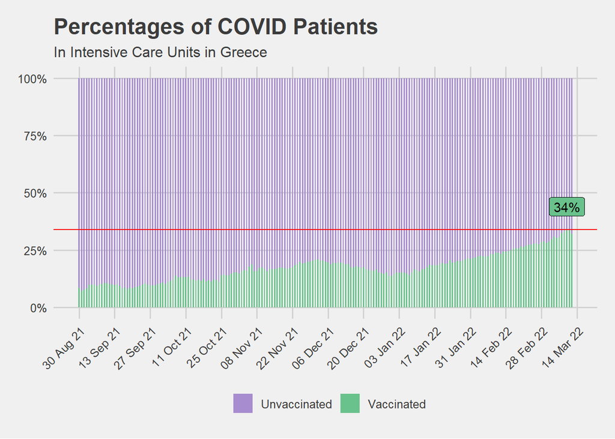

It’s stunning that vaccinated never surpass the number of 146 or 34 % in percentage.

## Distribution of Populations

By taking a look at the distributions of the numbers exhibited each day, we examine their numbers regardless of the days they occurred.

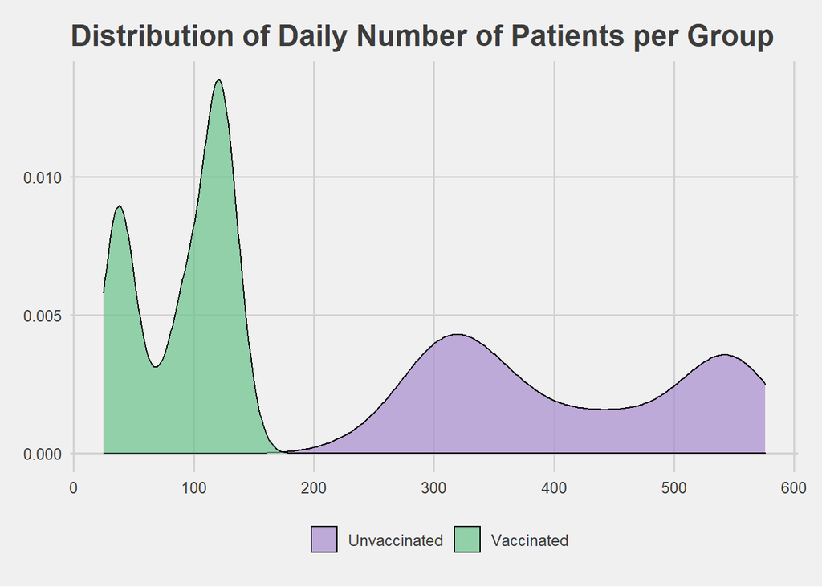

The numbers “scored” by the two groups make their distinction so blatant.

The highest numbers recorded by the vaccinated are even lower than the lowest of unvaccinated.

## Conlusion

Even though this current report is not a piece of extensive research and cannot directly suggest probabilities of ICU hospitalization, it provides a strong indication that vaccination contributes in avoiding the congestion of Intensive Care Units.